# Instacart.Rmd

Sonali Deole

9/13/2020

```r
knitr::opts_chunk$set(echo = TRUE)
```

##Introduction:

Instacart is an American company that operates as a same-day grocery delivery service. Customers can select groceries through a web application and the order is reviewed and delivered by personal shoppers through various retailers. With the large customer base, the company collects data of the users’ transactions behaviour and purchasing history.Instacart published the anonymized data on customer orders collected over time. Dataset consists 3 million grocery orders for more than 200,000 Instacart Orders.

There are three ways that Instacart generates revenue: delivery fees, membership fees, and mark-ups on in-store prices

In this analysis report,Exploratory Data analysis and Machine Learning was performed in order to derive insights from customer data.

##Research Goal & Objective The main objective of this analysis is to predict what will the user buy in the next order, given all data of prior orders.

##Data Source: Instacart released a public dataset, “The Instacart Online Grocery Shopping Dataset 2017”. The dataset contains over 3 million anonymized grocery orders from more than 200,000 Instacart users. This analysis will make use of this datasets. Data source can be downloaded here: https://www.kaggle.com/c/instacart-market-basket-analysis/data

##R Markdown #R libraries used Here is the list of libraries used for this Project

```r
#Here is the list of libraries used for this Project

library(data.table) # fast file reading
library(dplyr)
```

```r
library(ggplot2)
library(knitr)       # web widget
library(DT)
library(tidyr)
library(tidyverse)  # data manipulation
library(randomForest)
library(ROCR)       # rocr analysis
library(repr)
library(caret)      # rocr analysis
library(treemap)    # tree visualization
library(kableExtra) # nice table html formating
library(gridExtra)  # arranging ggplot in grid
#library(corrgram)   # correlation graphics
```

```r
##To know the current storage capacity
memory.limit()
```

```
## [1] 8067
```

```r
## To increase the storage capacity
memory.limit(size=100000)
```

```
## [1] 1e+05
```

##Importing the Dataset

```r
orders <- read_csv("orders.csv")
products <- read_csv('products.csv')
order_products_train <- read_csv('order_products__train.csv')
order_products_prior <- read_csv('order_products__prior.csv')
order_products <- read_csv('order_products__prior.csv')
aisles <- read_csv('aisles.csv')
departments <- read_csv('departments.csv')
```

##Data Insights:

The dataset is a relational set of files describing customers’ orders over time. They are anonymized and contains a sample of over 3 million grocery orders from more than 200,000 Instacart users. For each user, Instacart provided between 4 and 100 of their orders, with the sequence of products purchased in each order, the week and hour of day the order was placed, and a relative measure of time between orders.

Total six datasets were imported. Follwing section will explore each datasets in further detail. These datasets were sourced from an Kaggle competiotion (https://www.kaggle.com/c/instacart-market-basket-analysis/data)

orders (3.4m rows, 206k users):

order id: order identifier user_id: customer identifier eval_set: which evaluation set this order belongs in (see SET described below) order_number: the order sequence number for this user (1 = first, n = nth) order_dow: the day of the week the order was placed on order_hour_of_day: the hour of the day the order was placed on days_since_prior: days since the last order, capped at 30 (with NAs for order_number = 1) products (50k rows):

product_id: product identifier product_name: name of the product aisle_id: foreign key department_id: foreign key aisles (134 rows):

aisle_id: aisle identifier aisle: the name of the aisle deptartments (21 rows):

department_id: department identifier department: the name of the department order_products__SET (30m+ rows):

order_id: foreign key product_id: foreign key add_to_cart_order: order in which each product was added to cart reordered: 1 if this product has been ordered by this user in the past, 0 otherwise where SET is one of the four following evaluation sets (eval_set in orders):

“prior”: orders prior to that users most recent order (~3.2m orders) “train”: training data supplied to participants (~131k orders) “test”: test data reserved for machine learning competitions (~75k orders)

##Understanding and Exploring the data #Aisles: Total 134 ailes are present in this dataset. Here is a example of few aisles

```r
paste(sort(head(aisles$aisle)), collapse=', ')
```

```
## [1] "energy granola bars, instant foods, marinades meat preparation, other, prepared soups salads, specialty cheeses"
```

##Departments: There are total of 21 departments in this dataset. Below is the list of departments listed

```r
paste(sort(departments$department), collapse = ', ')
```

```
## [1] "alcohol, babies, bakery, beverages, breakfast, bulk, canned goods, dairy eggs, deli, dry goods pasta, frozen, household, international, meat seafood, missing, other, pantry, personal care, pets, produce, snacks"
```

##Products: There are 49,688 products in the catalogue within 134 aisles and 21 departments. Sample products are as below.

```r
products %>% head %>% kable
```

| product_id | product_name | aisle_id | department_id |
| --- | --- | --- | --- |
| 1 | Chocolate Sandwich Cookies | 61 | 19 |
| 2 | All-Seasons Salt | 104 | 13 |
| 3 | Robust Golden Unsweetened Oolong Tea | 94 | 7 |
| 4 | Smart Ones Classic Favorites Mini Rigatoni With Vodka Cream Sauce | 38 | 1 |
| 5 | Green Chile Anytime Sauce | 5 | 13 |
| 6 | Dry Nose Oil | 11 | 11 |

##Departments and its Products: Below is a list of 5 products from each department.Product dataframe is related to Departments.

```r
left_join(departments, products) %>% select(department, product_name ) %>%
  group_by(department) %>%
  sample_n(5) %>%
  summarise(five_examples_product=paste(product_name, collapse=' || ')) %>% sample_n(5) %>% kable
```

| department | five_examples_product |
| --- | --- |
| international | Paste for Lamb Curry \|\| Jalapeno Nacho Slices Hot \|\| Tamarind Stir-Fry Paste \|\| Shiitake Dried Black Mushrooms \|\| Split Pea with Barley Soup Mix |
| beverages | Organic Original Coconut Smoothie \|\| Mango Passionfruit Kombucha \|\| White Rose Kombucha \|\| Organic Roasted Dandelion Root Herbal Tea \|\| Guayusa Beverage, Sparkling, Original Zero with a Hint o… |
| pantry | Original Unflavored Gelatine \|\| White Cake Mix \|\| Dill Dip \|\| White Creamy Frosting \|\| Raspberry Gelatin Dessert |
| dry goods pasta | Pesto & Mozzarella Ravioli \|\| Organic Spelt Berries \|\| Classic Lasagna Velveeta Cheesy Skillets \|\| Medium Spicy Butter Chicken Simmer Sauce \|\| Cilantro Lime Rice |
| breakfast | Blueberry Chia Buckwheat Muesli \|\| Real Medleys Summer Berry Oatmeal Cup \|\| Organic Love Crunch Dark Chocolate Macaroon Granola \|\| Special K Heavenly Caramel Brownies \|\| Nut & Honey Snack Gran… |

##Aisles and its Products: Products dataframe is also related to aisles. Each aisle relates to multiple prodcuts. By joining both aisles and products dataframe, we have an idea what type of prodcuts for each ailes. Example below shows sample of aisles and few of its related products.

```r
left_join(aisles, products) %>%
  select(aisle, product_name ) %>%  group_by(aisle) %>%
  sample_n(5) %>%
  summarise(five_examples_product=paste(product_name, collapse=' || ')) %>% sample_n(5) %>% kable
```

| aisle | five_examples_product |
| --- | --- |
| first aid | Safe Travels First Aid Kit \|\| Elastic Bandage With Clips for Customized Compression \|\| Clear The Air Purifying Blend \|\| Maximum Strength Anti Itch Ointment \|\| Alcohol Prep Swabs |
| lunch meat | Smoked Pulled Pork \|\| Cabrese Salame \|\| Natural Choice Smoked Deli Ham \|\| Pre-Sliced Deli Roast Beef \|\| Honey Roasted Turkey |
| packaged vegetables fruits | Baby Kale & Spinach Juicing Greens \|\| Organic Raspberries \|\| Organic Mini Sweet Peppers \|\| Northwest Fresh Cranberries \|\| Harvest Medley |
| hot dogs bacon sausage | Naturally Hickory Smoked Thick Cut Bacon \|\| Uncured Beef Hot Dogs \|\| Jimmy Dean Fully Cooked Original Pork Sausage Crumbles \|\| Beef Chorizo \|\| Bistro Style Polish Sausage |
| canned jarred vegetables | Bruschetta, Artichoke \|\| Extra Small Size Artichoke Hearts \|\| Tomatoes, Crushed, Organic \|\| Tomato Purée \|\| Crushed Tomatoes No Salt Added |

##Orders: Train Eval Set There are over 3 millions observations in orders dataset. Each row represent an unique order. Each variable potentially can be used as predictors. Let’s analyse the construct of one user. For example, user_id 1 had made 10 prior orders (order number from 1 to 10), last order is a train (eval_set).

```r
orders %>% filter (user_id==1) %>%
  kable %>%kable_styling(bootstrap_options = c("striped", "hover"))
```

| order_id | user_id | eval_set | order_number | order_dow | order_hour_of_day | days_since_prior_order |
| --- | --- | --- | --- | --- | --- | --- |
| 2539329 | 1 | prior | 1 | 2 | 08 | NA |
| 2398795 | 1 | prior | 2 | 3 | 07 | 15 |
| 473747 | 1 | prior | 3 | 3 | 12 | 21 |
| 2254736 | 1 | prior | 4 | 4 | 07 | 29 |
| 431534 | 1 | prior | 5 | 4 | 15 | 28 |
| 3367565 | 1 | prior | 6 | 2 | 07 | 19 |
| 550135 | 1 | prior | 7 | 1 | 09 | 20 |
| 3108588 | 1 | prior | 8 | 1 | 14 | 14 |
| 2295261 | 1 | prior | 9 | 1 | 16 | 0 |
| 2550362 | 1 | prior | 10 | 4 | 08 | 30 |
| 1187899 | 1 | train | 11 | 4 | 08 | 14 |

##Test Eval_Set Looking at another construct of orders, User_id 3 had made 12 orders before the final order labeled as test (eval_set) order. From the data we know that order_number is being recycled for each user. Instacart did not provide us the basket content for test order. This is in fact the target for prediction.

#This also means <user_id, product_id> made up the key for prediction

```r
orders %>% filter (user_id==3) %>%
  kable %>%kable_styling(bootstrap_options = c("striped", "hover"))
```

| order_id | user_id | eval_set | order_number | order_dow | order_hour_of_day | days_since_prior_order |
| --- | --- | --- | --- | --- | --- | --- |
| 1374495 | 3 | prior | 1 | 1 | 14 | NA |
| 444309 | 3 | prior | 2 | 3 | 19 | 9 |
| 3002854 | 3 | prior | 3 | 3 | 16 | 21 |
| 2037211 | 3 | prior | 4 | 2 | 18 | 20 |
| 2710558 | 3 | prior | 5 | 0 | 17 | 12 |
| 1972919 | 3 | prior | 6 | 0 | 16 | 7 |
| 1839752 | 3 | prior | 7 | 0 | 15 | 7 |
| 3225766 | 3 | prior | 8 | 0 | 17 | 7 |
| 3160850 | 3 | prior | 9 | 0 | 16 | 7 |
| 676467 | 3 | prior | 10 | 3 | 16 | 17 |
| 521107 | 3 | prior | 11 | 0 | 18 | 11 |
| 1402502 | 3 | prior | 12 | 1 | 15 | 15 |
| 2774568 | 3 | test | 13 | 5 | 15 | 11 |

##Order_Product Each order contain multiple products purchased by user. Instacart had cleanly categorized the orders into ‘train’ and ‘prior’ in SINGLE order dataset.

However, the detail of each orders are splitted into two datsets: - order_product_train: contain only detail product items of last order - order_product_prior: contain detail product items of all prior orders

##Order_Product_Train

```r
order_products_train %>% filter (order_id == 1187899) %>%
  kable %>% kable_styling(bootstrap_options = c("striped", "hover"))
```

| order_id | product_id | add_to_cart_order | reordered |
| --- | --- | --- | --- |
| 1187899 | 196 | 1 | 1 |
| 1187899 | 25133 | 2 | 1 |
| 1187899 | 38928 | 3 | 1 |
| 1187899 | 26405 | 4 | 1 |
| 1187899 | 39657 | 5 | 1 |
| 1187899 | 10258 | 6 | 1 |
| 1187899 | 13032 | 7 | 1 |
| 1187899 | 26088 | 8 | 1 |
| 1187899 | 27845 | 9 | 0 |
| 1187899 | 49235 | 10 | 1 |
| 1187899 | 46149 | 11 | 1 |

##Order_Product_Train_Prior Similary, detail items for a PRIOR ORDER (example order_id: 2550362) can be retireved by quering diffrent dataset order_product_prior.

```r
order_products_prior %>% filter (order_id == 2550362) %>%
  kable %>% kable_styling(bootstrap_options = c("striped", "hover"))
```

| order_id | product_id | add_to_cart_order | reordered |
| --- | --- | --- | --- |
| 2550362 | 196 | 1 | 1 |
| 2550362 | 46149 | 2 | 1 |
| 2550362 | 39657 | 3 | 0 |
| 2550362 | 38928 | 4 | 0 |
| 2550362 | 25133 | 5 | 1 |
| 2550362 | 10258 | 6 | 1 |
| 2550362 | 35951 | 7 | 0 |
| 2550362 | 13032 | 8 | 1 |
| 2550362 | 12427 | 9 | 1 |

##Users: Ther is no dedicated dataframe for users. However, we can derive number of unique users from order dataframe. By grouping the user_id and eval_set column, we found that there are 75,000 test users, 131,209 train users.

We shall use train users for training, and test users for testing.

```r
#table(orders$eval_set) %>% kable(col.names = c('eval_set','Frequency')) %>%   kable_styling(bootstrap_options = c("striped", "hover"), position = "float_right")

orders %>% filter(eval_set %in% c('train','test') ) %>%
  count(eval_set) %>%
  mutate(percentage=n/sum(n)) %>%
  kable %>% kable_styling(bootstrap_options = c("striped", "hover"))
```

| eval_set | n | percentage |
| --- | --- | --- |
| test | 75000 | 0.3637087 |
| train | 131209 | 0.6362913 |

##Exploratory Data Analysis: Understanding the buying behavior by answering the following questions? 1)What products do people buy and what do they usually reorder? 2)When do they buy? Does time of the day infleunce their buying behavior?

```r
tmp = orders %>% group_by(user_id) %>% summarize(n_orders = max(order_number))
```

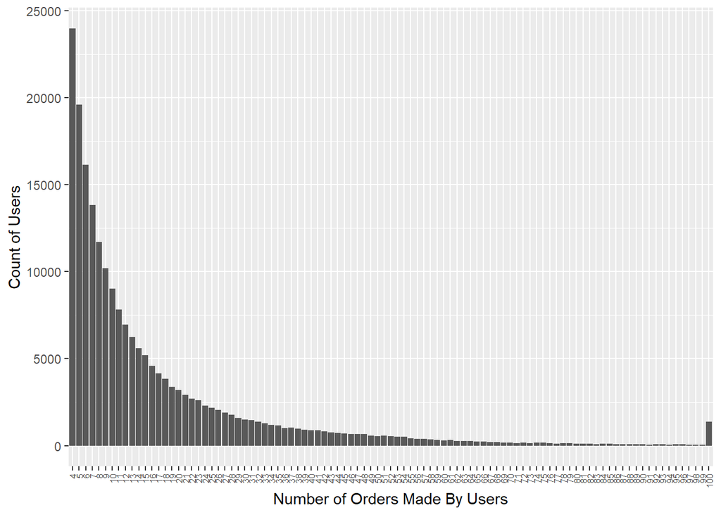

```r
tmp %>% ggplot(aes(x=as.factor(n_orders))) + geom_bar() +
    ylab('Count of Users') +
    xlab('Number of Orders Made By Users') +
    theme(
      axis.text.x  = element_text (size = 6.0, angle = (90), hjust = 1, vjust = 0.5)
    )
```

##How Soon Until Next Order ? It is very obvious that most users made their orders weekly (every 7 days) and monthly (every 30 days). See the peak of day 7 and day 30 in the chart below.

```r
tmp = orders %>%
  filter(order_number>1) %>% # days_since_prior is NA for first order, need to filter out
  group_by(order_id) %>%
    summarize(n_orders = max(days_since_prior_order))
```

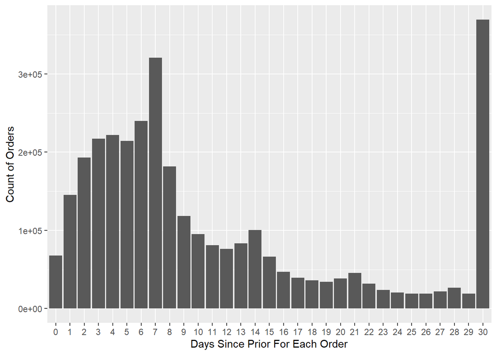

```r
tmp %>% ggplot(aes(x=as.factor(n_orders))) + geom_bar() + ylab('Count of Orders') + xlab('Days Since Prior For Each Order')
```

##Orders_Products: Most Popular Products Sold We know that banana are the most popular products. The number of orders varies greatly for different products. Illustration below uses shows sample of only 30 top products. Notice however the varience is not obvious after top 10 products.

```r
tmp = order_products_train %>%
  left_join(products) %>%
  group_by(product_name) %>%
  summarize(count=n()) %>%
  top_n(n=30, wt=count) %>%  mutate(percentage=count/sum(count))
```

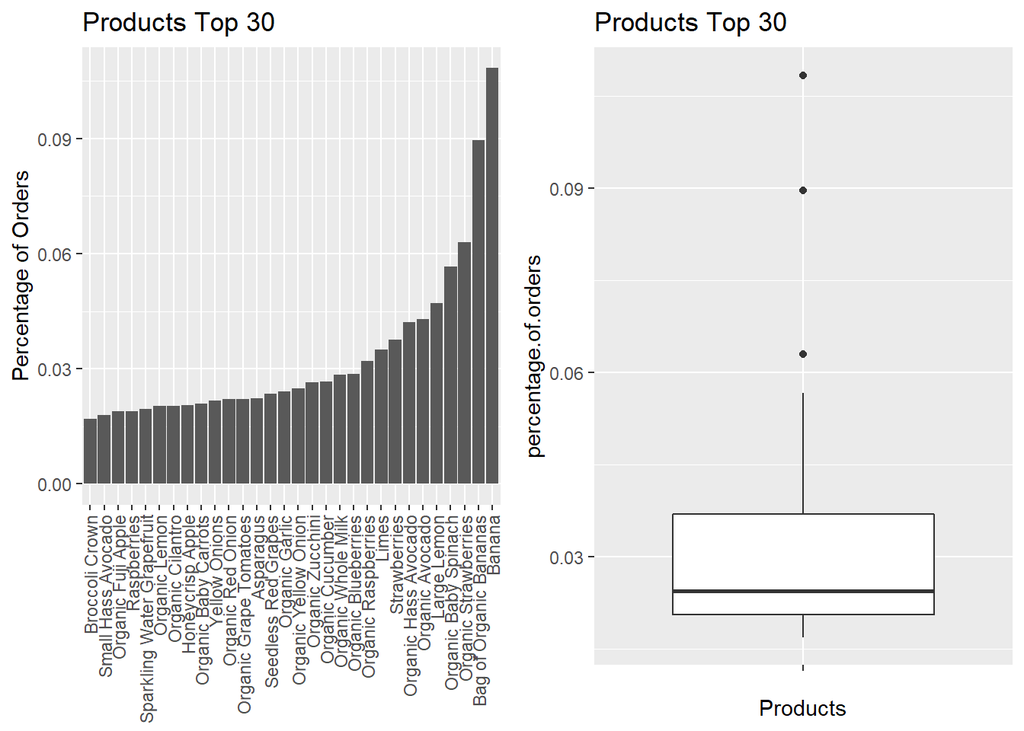

```r
p1 = ggplot (tmp, aes(x=reorder(product_name,count), y=percentage)) +
  geom_col() + ggtitle('Products Top 30') + ylab('Percentage of Orders') +
  theme (
    axis.text.x=element_text(angle=90, hjust=1, vjust=0.5),
    axis.title.x = element_blank())
p2 = ggplot (data = tmp, aes( x= '', y=percentage )) +
  ggtitle('Products Top 30') + ylab('percentage.of.orders') + geom_boxplot() + xlab('Products')
grid.arrange(p1, p2, ncol = 2)
```

##Most Popular Department Sold: Certain departmens are clearly more popular, like produce and dairy eggs. Both deparments combined contributed to more than 40% of total orders.

```r
tmp = order_products_train %>%
  left_join(products) %>%
  left_join(departments) %>%
  group_by(department) %>%
  summarize(count=n()) %>%
  mutate(percentage=count/sum(count))
```

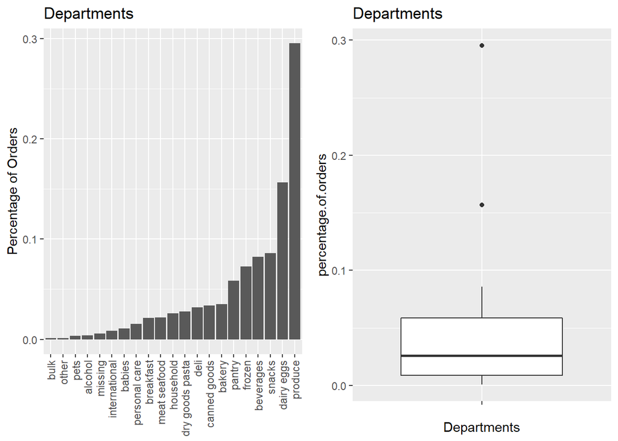

```r
p1 = ggplot (tmp, aes(x=reorder(department,count), y=percentage)) +
  geom_col() + ggtitle('Departments') + ylab('Percentage of Orders') +
  theme (
    axis.text.x=element_text(angle=90, hjust=1, vjust=0.5),
    axis.title.x = element_blank())
p2 = ggplot (data = tmp, aes( x= '', y=percentage )) +
  ggtitle('Departments') + ylab('percentage.of.orders') + geom_boxplot() + xlab('Departments')
grid.arrange(p1, p2, ncol = 2)
```

```r
##To know the current storage capacity
memory.limit()
```

```
## [1] 1e+05
```

```r
## To increase the storage capacity
memory.limit(size=100000)
```

```
## [1] 1e+05
```

##Most Popular Aisles Sold: We looked into the buying trend of product by ailes and notice that certain aisle like vegetables and fruits contributes to almost 30% of total orders. Chart below shows top 30 aisles.

```r
tmp = order_products_prior %>%
  left_join(products) %>%
  left_join(aisles) %>%
  group_by(aisle) %>%
  summarize(count=n()) %>%
  top_n(n=30, wt=count) %>%  mutate(percentage=count/sum(count))
```

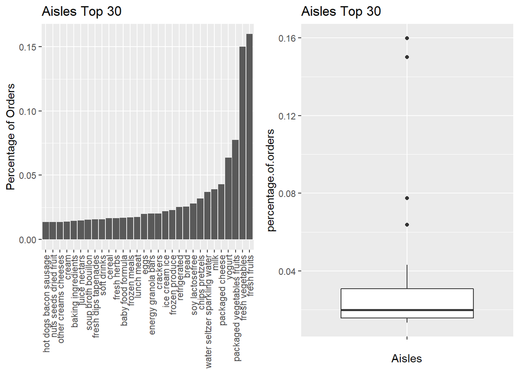

```r
p1 = ggplot (tmp, aes(x=reorder(aisle,count), y=percentage)) +
  geom_col() + ggtitle('Aisles Top 30') + ylab('Percentage of Orders') +
  theme (
    axis.text.x=element_text(angle=90, hjust=1, vjust=0.5),
    axis.title.x = element_blank()) +  ylab('Percentage of Orders') + xlab('Aisles')
p2 = ggplot (tmp, aes( x= '', y=percentage )) +
  ggtitle('Aisles Top 30') + ylab('percentage.of.orders') + geom_boxplot() + xlab('Aisles')
grid.arrange(p1, p2, ncol = 2)
```

##Products Ordered Day Pattern: We can see that both Day 0 and Day 1 stands out to be the most busy shopping day for instacart. This means that day of order made may influence the basket size.

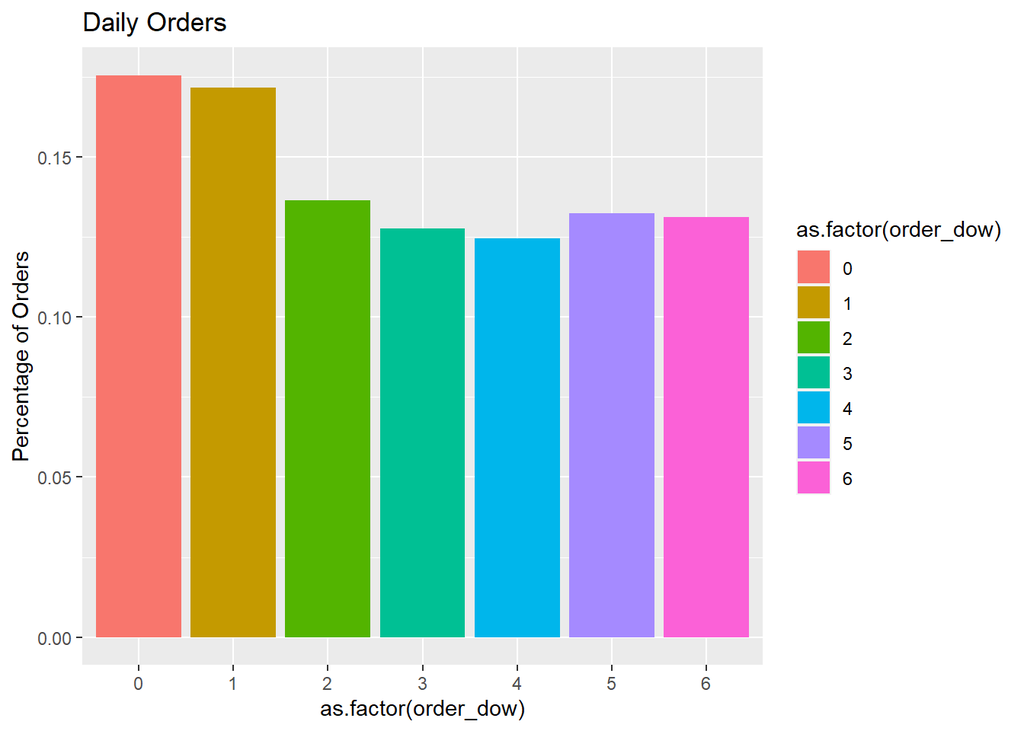

```r
orders %>%
  group_by(order_dow) %>%
    summarize(count = n()) %>%
  mutate(percentage=count/sum(count)) %>%
  ggplot (aes(x=as.factor(order_dow), y=percentage, fill=as.factor(order_dow))) +
    geom_col()+ ylab('Percentage of Orders') + ggtitle('Daily Orders')
```

##Hourly Products Ordered: Morning to afternoon is the peak time when customers place their orders. Clearly the time of the day influcences the buying behavior.

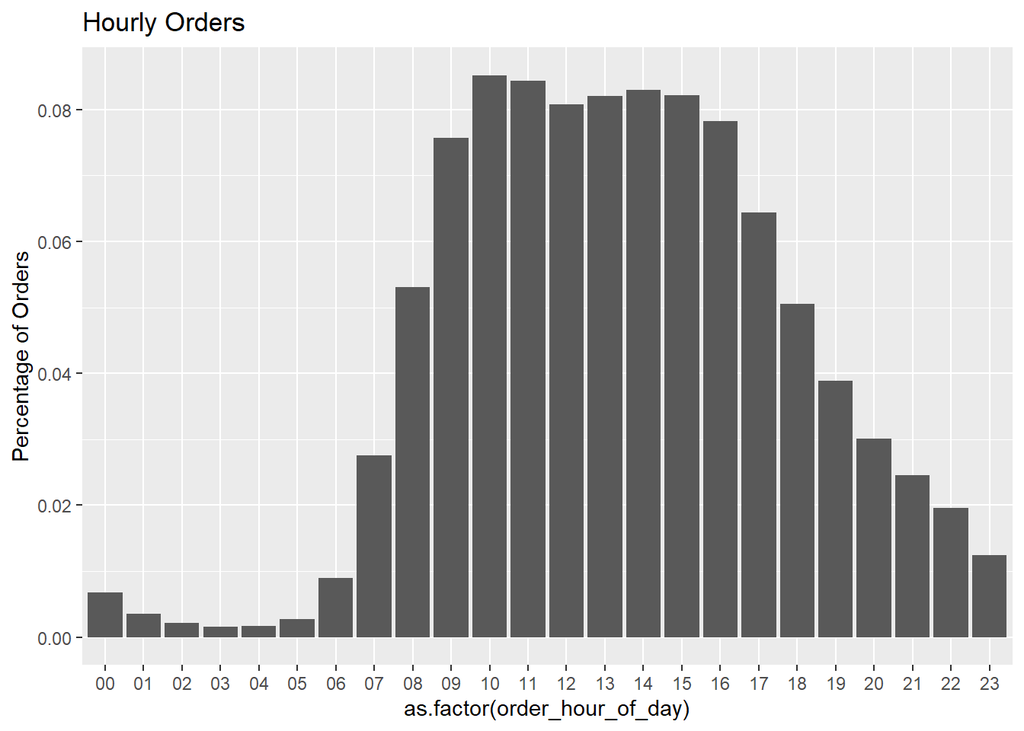

```r
order_products_prior %>%
  left_join(orders) %>%
  group_by(order_hour_of_day) %>%
  summarize(count = n()) %>%
  mutate(percentage=count/sum(count)) %>%
  ggplot (aes(x=as.factor(order_hour_of_day), y=percentage)) +
    geom_col()+ ylab('Percentage of Orders') + ggtitle('Hourly Orders')
```

##Top 10 products managed to score betwen 6% to 8% of hourly sales out of 50,000 products. Every hour has slightly different combination of top 10 products (combination out of 12 products). That means certain products are predictable for ordering irregardless of the hour of order.

```r
##To know the current storage capacity
memory.limit()
```

```
## [1] 1e+05
```

```r
## To increase the storage capacity
memory.limit(size=100000)
```

```
## [1] 1e+05
```

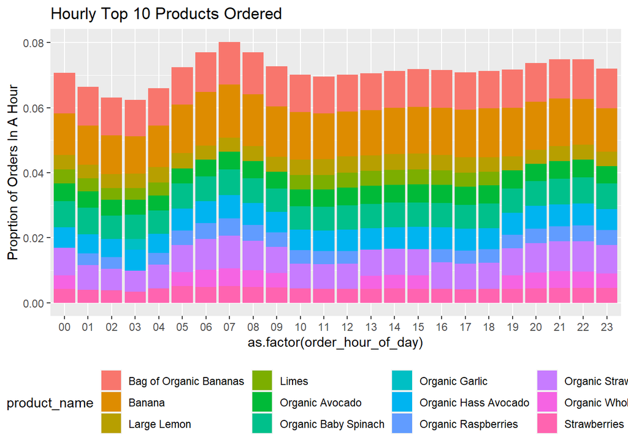

```r
order_products_prior %>%
  left_join(orders) %>% left_join(products) %>%
  group_by(order_hour_of_day, product_name) %>%
  summarize(n=n()) %>%
  mutate(percentage=n/sum(n)) %>%
  top_n(10, wt=n) %>%
  ggplot (aes(x=as.factor(order_hour_of_day), y=percentage, fill=product_name)) +
    geom_col() + ylab('Proprtion of Orders In A Hour') + ggtitle('Hourly Top 10 Products Ordered') +
    theme(legend.position="bottom",legend.direction="horizontal")
```

```r
tmp = order_products_prior %>%
  group_by(order_id)  %>%
  summarize( basket_size=n(),
             reordered_items = sum(reordered)) %>%
  group_by(basket_size) %>%
  summarize(n=n(), avg_reordered_items =mean(reordered_items)) %>%
  arrange(basket_size)
```

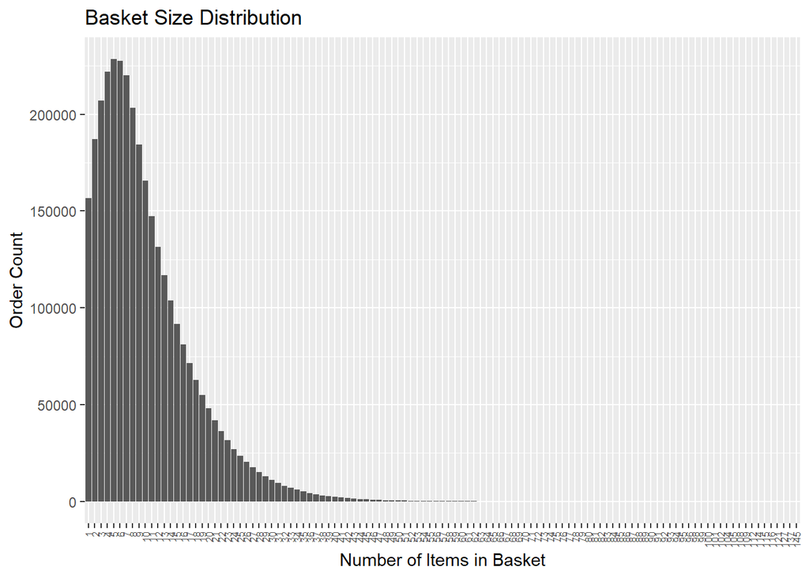

```r
tmp %>% ggplot(aes(x=as.factor(basket_size))) +
    geom_col(aes(y=n)) +
    ylab('Order Count') +
    xlab('Number of Items in Basket') +
    ggtitle('Basket Size Distribution') +
    theme(
      axis.text.x  = element_text (size = 6.0, angle = (90), hjust = 1, vjust = 0.5)
    )
```

##Re-Ordered Analysis Analyzing the re-ordered products is the most important part of the EDA. This is becasue insights from this analysis can help to develop intuition for furhter feature engineering that will make the prediction more meaningful.

#Average Re-ordered Items In Basket Distribution

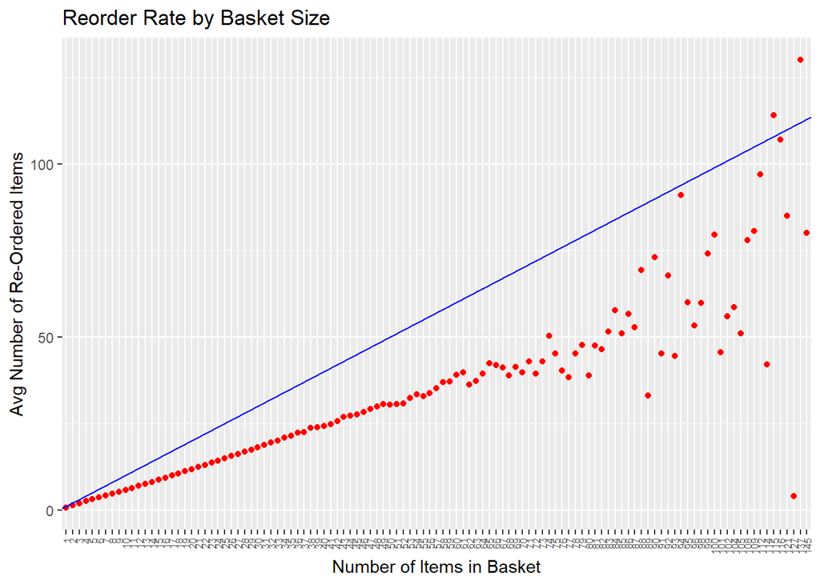

```r
tmp %>% ggplot (aes(x=as.factor(basket_size))) +
    geom_point(aes(y=avg_reordered_items), color='red') +
    ylab('Avg Number of Re-Ordered Items') +
    xlab('Number of Items in Basket') +
    ggtitle('Reorder Rate by Basket Size') +
    theme(
      axis.text.x  = element_text (size = 6.0, angle = (90), hjust = 1, vjust = 0.5)
    ) +
    geom_abline(intercept = 0, slope = 1, color='blue')
```

##Reordering: How often do people order the same items again? 59% of the ordered items are reorders.

```r
tmp <- order_products_train %>%
  group_by(reordered) %>%
  summarize(count = n()) %>%
  mutate(reordered = as.factor(reordered)) %>%
  mutate(proportion = count/sum(count))
kable (tmp)
```

| reordered | count | proportion |
| --- | --- | --- |
| 0 | 555793 | 0.4014056 |
| 1 | 828824 | 0.5985944 |

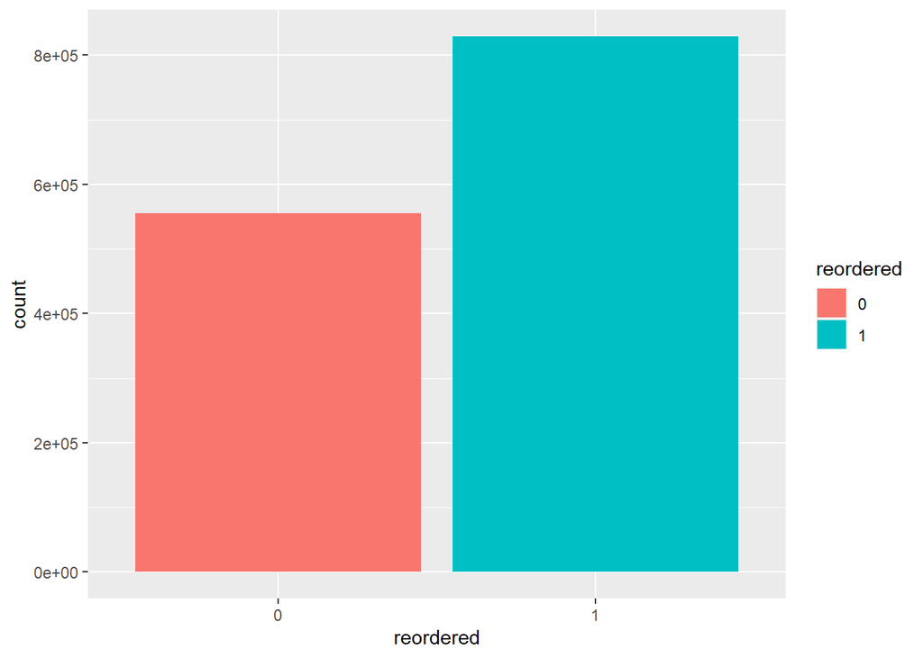

```r
tmp %>%
  ggplot(aes(x=reordered,y=count,fill=reordered))+
  geom_bar(stat="identity")
```

##Most often reordered: Lets find out the products that have highest probability of being reordered. These 10 products have the highest probability of being reordered.

```r
tmp <-order_products_train %>%
  group_by(product_id) %>%
  summarize(proportion_reordered = mean(reordered), n=n()) %>%
  filter(n>40) %>%
  top_n(10,wt=proportion_reordered) %>%
  arrange(desc(proportion_reordered)) %>%
  left_join(products,by="product_id")
kable(tmp)
```

| product_id | proportion_reordered | n | product_name | aisle_id | department_id |
| --- | --- | --- | --- | --- | --- |
| 1729 | 0.9347826 | 92 | 2% Lactose Free Milk | 84 | 16 |
| 20940 | 0.9130435 | 368 | Organic Low Fat Milk | 84 | 16 |
| 12193 | 0.8983051 | 59 | 100% Florida Orange Juice | 98 | 7 |
| 21038 | 0.8888889 | 81 | Organic Spelt Tortillas | 128 | 3 |
| 31764 | 0.8888889 | 45 | Original Sparkling Seltzer Water Cans | 115 | 7 |
| 24852 | 0.8841717 | 18726 | Banana | 24 | 4 |
| 117 | 0.8833333 | 120 | Petit Suisse Fruit | 2 | 16 |
| 39180 | 0.8819876 | 483 | Organic Lowfat 1% Milk | 84 | 16 |
| 12384 | 0.8810409 | 269 | Organic Lactose Free 1% Lowfat Milk | 91 | 16 |
| 24024 | 0.8785249 | 461 | 1% Lowfat Milk | 84 | 16 |

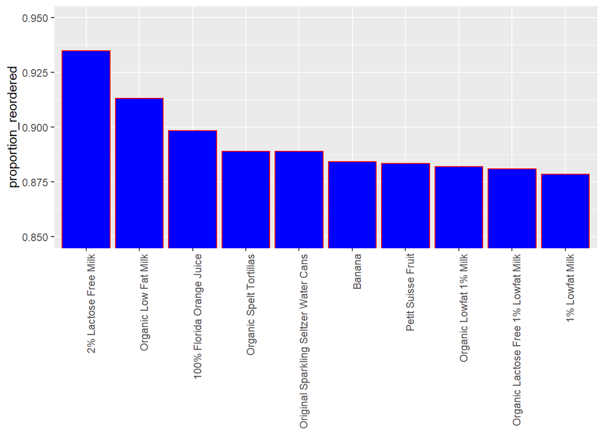

```r
tmp %>%
  ggplot(aes(x=reorder(product_name,-proportion_reordered), y=proportion_reordered))+
  geom_bar(stat="identity",col = "red", fill="blue")+
  theme(axis.text.x=element_text(angle=90, hjust=1),axis.title.x = element_blank())+coord_cartesian(ylim=c(0.85,0.95))
```

##Which item do people put into the cart first? People seem to be quite certain about Multifold Towels and if they buy them, put them into their cart first in 66% of the time.

```r
tmp <- order_products_train %>%
  group_by(product_id, add_to_cart_order) %>%
  summarize(count = n()) %>% mutate(pct=count/sum(count)) %>%
  filter(add_to_cart_order == 1, count>10) %>%
  arrange(desc(pct)) %>%
  left_join(products,by="product_id") %>%
  select(product_name, pct, count) %>%
  ungroup() %>%
  top_n(10, wt=pct)
kable(tmp)
```

| product_id | product_name | pct | count |
| --- | --- | --- | --- |
| 45004 | White Multifold Towels | 0.6610169 | 39 |
| 11885 | Sparkling Water, Bottles | 0.5942029 | 41 |
| 13128 | Purified Alkalkine Water with Minerals pH10 | 0.5714286 | 12 |
| 4100 | Organic Dark Roast | 0.5600000 | 14 |
| 1729 | 2% Lactose Free Milk | 0.5217391 | 48 |
| 6729 | Cookie Tray | 0.4861111 | 35 |
| 9285 | Boneless Pork Shoulder Butt | 0.4814815 | 13 |
| 6848 | Party Tumblers | 0.4615385 | 12 |
| 12640 | Sport Bottle with Flip Cap Natural Spring Water | 0.4615385 | 12 |
| 26405 | XL Pick-A-Size Paper Towel Rolls | 0.4476190 | 47 |

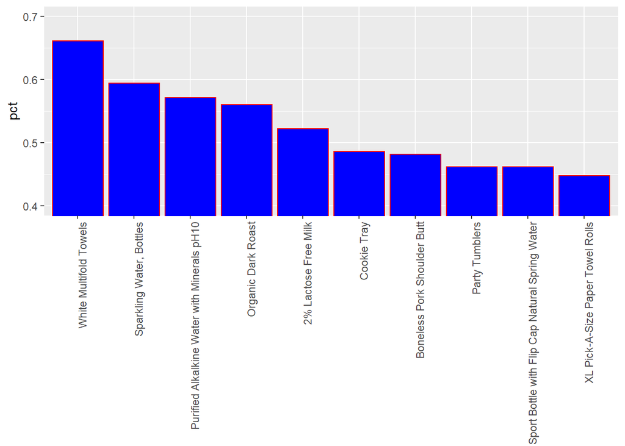

```r
tmp %>%
  ggplot(aes(x=reorder(product_name,-pct), y=pct))+
  geom_bar(stat="identity",col = "red", fill="blue")+
  theme(axis.text.x=element_text(angle=90, hjust=1),axis.title.x = element_blank())+coord_cartesian(ylim=c(0.4,0.7))
```

##Association between time of last order and probability of reorder This is interesting: We can see that if people order again on the same day, they order the same product more often. Whereas when 30 days have passed, they tend to try out new things in their order.

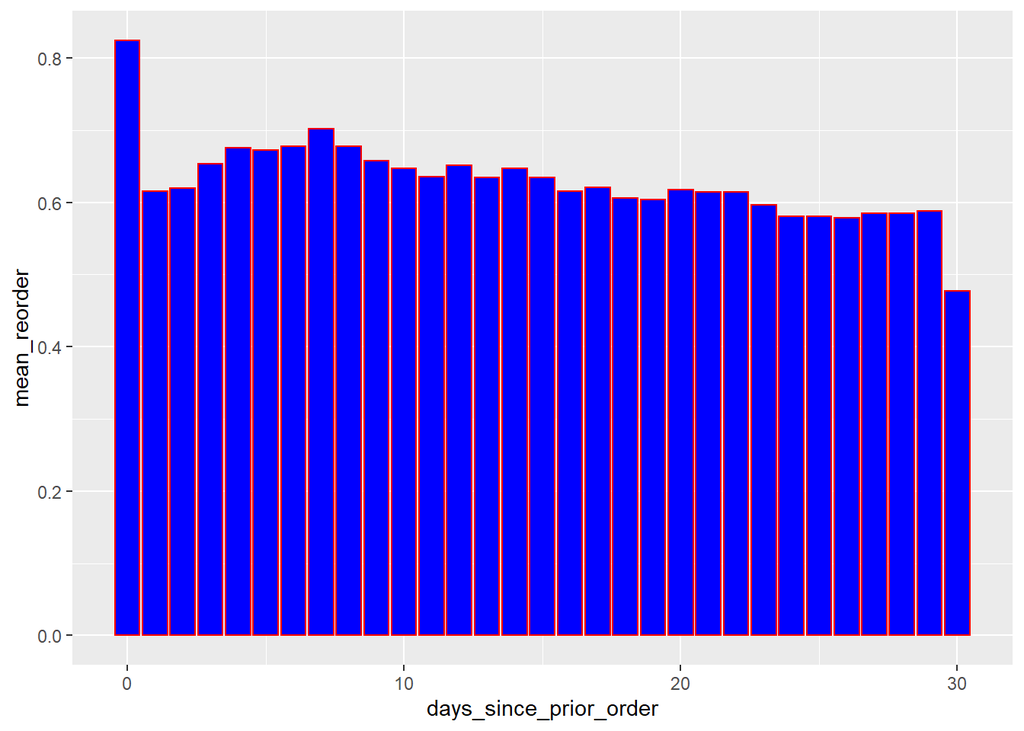

```r
order_products_train %>%
  left_join(orders,by="order_id") %>%
  group_by(days_since_prior_order) %>%
  summarize(mean_reorder = mean(reordered)) %>%
  ggplot(aes(x=days_since_prior_order,y=mean_reorder))+
  geom_bar(stat="identity",col = "red", fill="blue")
```

##Association between number of orders and probability of reordering Products with a high number of orders are naturally more likely to be reordered. However, there seems to be a ceiling effect.

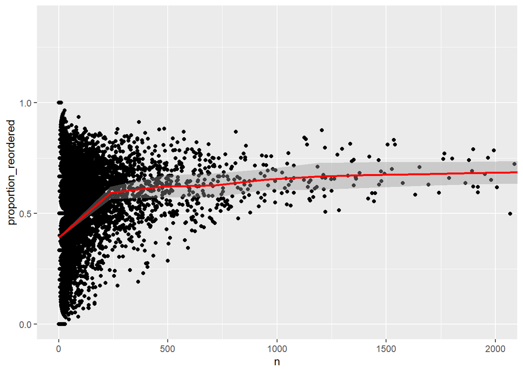

```r
order_products_train %>%
  group_by(product_id) %>%
  summarize(proportion_reordered = mean(reordered), n=n()) %>%
  ggplot(aes(x=n,y=proportion_reordered))+
  geom_point()+
  geom_smooth(color="red")+
  coord_cartesian(xlim=c(0,2000))
```

##Organic vs Non-organic What is the percentage of orders that are organic vs. not organic?

```r
  products <- products %>%
  mutate(organic=ifelse(str_detect(str_to_lower(products$product_name),'organic'),"organic","not organic"),
         organic= as.factor(organic))

tmp <- order_products_train %>%
  left_join(products, by="product_id") %>%
  group_by(organic) %>%
  summarize(count = n()) %>%
  mutate(proportion = count/sum(count))
kable(tmp)
```

| organic | count | proportion |
| --- | --- | --- |
| not organic | 979000 | 0.7070547 |
| organic | 405617 | 0.2929453 |

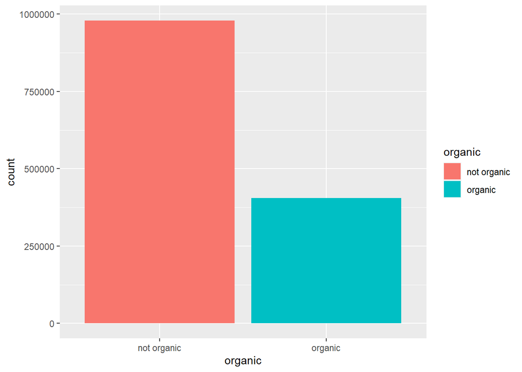

```r
tmp %>%
  ggplot(aes(x=organic,y=count, fill=organic))+
  geom_bar(stat="identity")
```

##Reordering Organic vs Non-Organic People more often reorder organic products than in-organic products.

```r
tmp <- order_products_train %>% left_join(products,by="product_id") %>% group_by(organic) %>% summarize(mean_reordered = mean(reordered))
kable(tmp)
```

| organic | mean_reordered |
| --- | --- |
| not organic | 0.5784985 |
| organic | 0.6470981 |

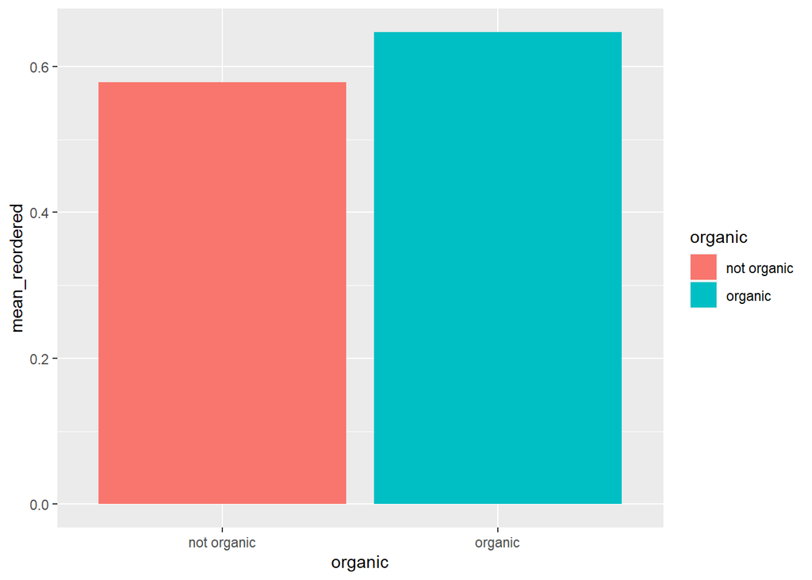

```r
tmp %>% ggplot(aes(x=organic,fill=organic,y=mean_reordered))+geom_bar(stat="identity")
```

##Visualizing the Product Portfolio Here is use to treemap package to visualize the structure of instacarts product portfolio. In total there are 21 departments containing 134 aisles.

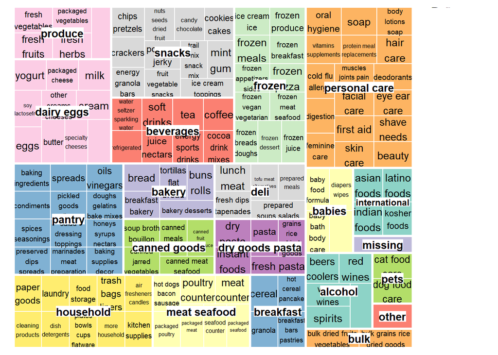

```r
library(treemap)
tmp <- products %>% group_by(department_id, aisle_id) %>% summarize(n=n())
tmp <- tmp %>% left_join(departments,by="department_id")
tmp <- tmp %>% left_join(aisles,by="aisle_id")

tmp2<-order_products_train %>%
  group_by(product_id) %>%
  summarize(count=n()) %>%
  left_join(products,by="product_id") %>%
  ungroup() %>%
  group_by(department_id,aisle_id) %>%
  summarize(sumcount = sum(count)) %>%
  left_join(tmp, by = c("department_id", "aisle_id")) %>%
  mutate(onesize = 1)
treemap(tmp2,index=c("department","aisle"),vSize="onesize",vColor="department",
        palette="Set3",title="",sortID="-sumcount", border.col="#FFFFFF",type="categorical",
        fontsize.legend = 0,bg.labels = "#FFFFFF")
```

##How many unique products are offered in each department/aisle? The size of the boxes shows the number of products in each category.

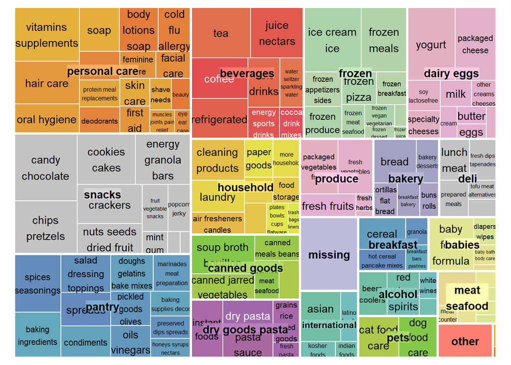

```r
treemap(tmp,index=c("department","aisle"),vSize="n",title="",palette="Set3",border.col="#FFFFFF")
```

##How often are products from the department/aisle sold? The size of the boxes shows the number of sales.

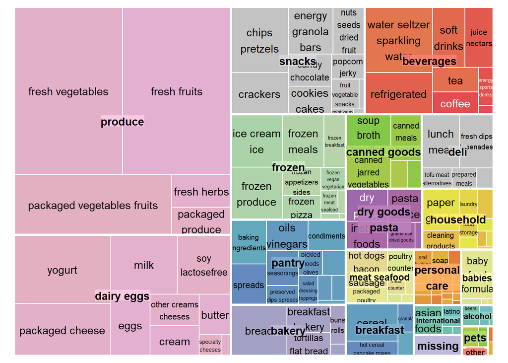

```r
treemap(tmp2,index=c("department","aisle"),vSize="sumcount",title="",palette="Set3",border.col="#FFFFFF")
```

##Exploring Customer Habits Customers who reorder the same products again all the time. 3,487 customers always reordering products. Customers reordering only

```r
tmp <- order_products_prior %>%
  group_by(order_id) %>%
  summarize(m = mean(reordered),n=n()) %>%
  right_join(filter(orders,order_number>2), by="order_id")
tmp2 <- tmp %>%
  filter(eval_set =="prior") %>%
  group_by(user_id) %>%
  summarize(n_equal = sum(m==1,na.rm=T), percent_equal = n_equal/n()) %>%
  filter(percent_equal == 1) %>%
  arrange(desc(n_equal))
datatable(tmp2, class="table-condensed", style="bootstrap", options = list(dom = 'tp'))
```

|  | user_id | n_equal | percent_equal |
| --- | --- | --- | --- |
| 1 | 99753 | 97 | 1 |
| 2 | 55331 | 49 | 1 |
| 3 | 106510 | 49 | 1 |
| 4 | 111365 | 47 | 1 |
| 5 | 74656 | 46 | 1 |
| 6 | 170174 | 45 | 1 |
| 7 | 12025 | 43 | 1 |
| 8 | 164779 | 37 | 1 |
| 9 | 37075 | 34 | 1 |
| 10 | 110225 | 33 | 1 |

[output cut: 3477 more lines]

##Here is an example to the customer with a stong habit of always reordering the same product. Customer id #99753, having 97 orders with only reordered items. She/he seems to like Organic Milk :-) One would assume that he would buy “Organic Whole Milk” and “Organic Reduced Fat Milk”:

```r
tmp <- orders %>% filter(user_id==99753, eval_set == "train")
tmp2 <- order_products_train %>%
  filter(order_id == tmp$order_id) %>%
  left_join(products, by="product_id")

datatable(select(tmp2,-aisle_id,-department_id,-organic), style="bootstrap", class="table-condensed", options = list(dom = 't'))
```

|  | order_id | product_id | add_to_cart_order | reordered | product_name |
| --- | --- | --- | --- | --- | --- |
| 1 | 3143182 | 27845 | 1 | 1 | Organic Whole Milk |
| 2 | 3143182 | 38689 | 2 | 1 | Organic Reduced Fat Milk |

##Top 10 aisles that represent the 45.3% of sales:

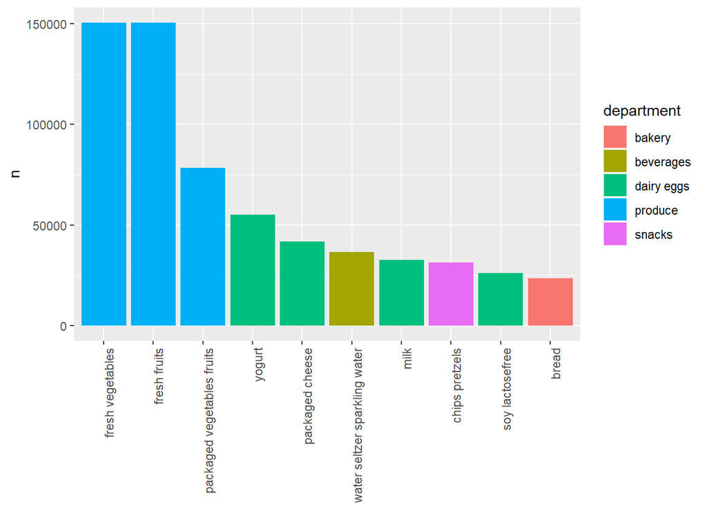

```r
tmp <- order_products_train %>%
  left_join(products,by="product_id") %>%
  left_join(aisles,by="aisle_id") %>%
  left_join(departments,by="department_id") %>%
  group_by(aisle,department) %>%
  tally(sort=TRUE) %>%
  mutate(perc = round(100*n/nrow(order_products_train),2)) %>%
  ungroup() %>%
  top_n(10,n)
tmp %>%
  ggplot(aes(x=reorder(aisle, -n), y=n, fill=department)) +
  geom_bar(stat="identity") +
  theme(axis.text.x=element_text(angle=90, hjust=1), axis.title.x = element_blank())
```